# 02Fig2H_MO_H3K4me3_aSTRING

Dr. Julio Domingo Cordero Henriquez

Department of Cardiovascular Genomics and Epigenomics, European Center for Angioscience (ECAS), Medical Faculty Mannheim, Heidelberg University, Mannheim, Germany

19 January 2024

# Contents

Mailto: julio.cordero@medma.uni-heidelberg.de

# 1 **Objective**

- To integrate the STRING-Web output file from Protein-Protein interactions associated with H3K4me3 ChIP-seq.

# 2 General Comments on the Script

- Usually, diverse transcriptional factor **TF** proteins are associated with the peak areas of associated Histone mark ChIP-seq. Here we handle **STRING-Web results from known protein-protein interactions**. The classification is performed by counting the number of known interactions that the proteins have. This script could be customized to handle any output text file with protein-protein interactions. The output text result from this script could serve as an input network for the Cytoscape program.

# 3 Summary of figures produced by this script.

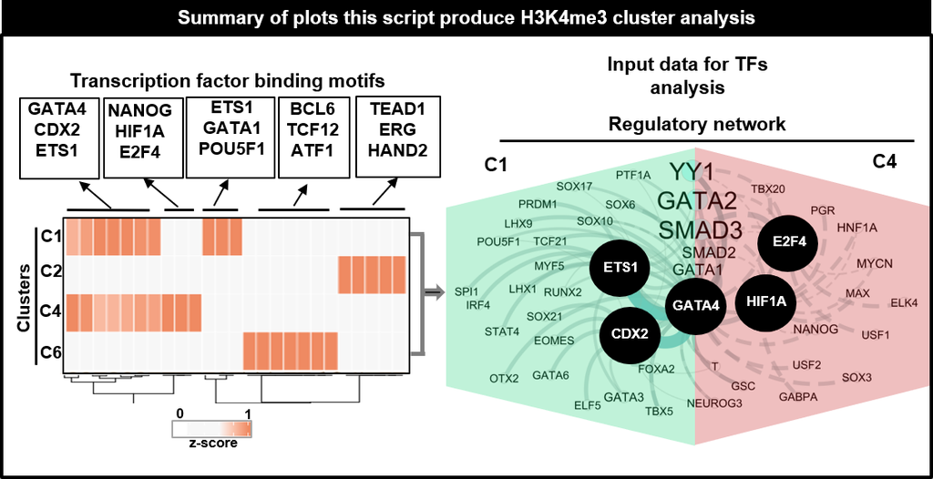

# 4 Set the working environment and folder to output the results

- Important to keep the output files well organized following the FAIR principles
- Findable, Accessible, Interoperable, and Reusable **(FAIR)**

```r
 workdir = "./"
setwd(workdir)
PTHA1="../03OUTPUT/"
dir.create(PTHA1)
PORT="../03OUTPUT/"
PROJECT="02Fig2H_MO_H3K4me3_aSTRING"
PORT=paste(PTHA1,PROJECT,"/",sep="")
dir.create(PTHA1)
dir.create(PORT)
NAME33<- c("Mo_Name","Consensus","P-value","Log_P-value","q-value_Benja","Nor_of_Tar","Per_of_Tar","No_of_Tar_Backg","Per_of_Tar_Backg")
NAME34<- c("HOmer_NAME",NAME33)
NAME56<- c("Description","Plog10","REG")
NAME_MO<- c("Mo_Name","Plog10","REG")
WORK1="../01DATA/aSTRING/"
NAME_G1 <- data.frame(list.files(path=WORK1,pattern="*.tsv",all.files = T,full.names = T, recursive = T))
NAME_G2 <- data.frame(list.files(path=WORK1,pattern="*.tsv",all.files = F,full.names = F, recursive = T))

NAME_G2$Mo_Name2 <- gsub("*_Protein_string_interactions_short.tsv", "", NAME_G2[,1])
REP=1:length(unique(NAME_G2[,1]))
CL<- data.frame(NAME_G2[,2])
NAME_G2$CLU<- NAME_G2$Mo_Name2
######## group of motifs
colnames(NAME_G2)<- c("ENH4","Mo_Name2","CLU")
NAME_G2b<- t(NAME_G2[,2])
```

# 5 Import the data

## 5.1 Import the different matrixes and merging together

```r
### TO read all files from String in one LOOP
mat_PEAKS2<- list()
for(i in 1:length(NAME_G2[,1])) {
MO<- NAME_G2[i,3]
mat_PEAKS2[[MO]] = read.delim(NAME_G1[i,1],header=T,check.names=FALSE, stringsAsFactors=FALSE,sep="\t")
mat_PEAKS2[[MO]]$CLU<- MO
}
GN5a<- do.call(rbind, mat_PEAKS2)
```

## 5.2 Count the interactions from the matrixes obtained from String

```r
MA6<- data.frame(table(GN5a$node1,GN5a$CLU))
MA6<- subset(MA6, Freq>=1 )
colnames(MA6)<- c("node1","CLU","Freq")
FIL<- data.matrix(summary(MA6$Freq))
FIL2<-as.numeric(round(FIL[2,1],digits = 2))
FIL5<-as.numeric(round(FIL[5,1],digits = 2))
FIL4<-as.numeric(round(FIL[4,1],digits = 2))
MA7<- subset(MA6, Freq>=1 )
MA74<- subset(MA6, Freq>=1 )
differ_4 = merge(GN5a,MA7, by= "node1")
MA7_46<- subset(differ_4, Freq>= FIL5 )
```

# 6 Subset the Top 10 of TFs

# 7 Visualization of the data

## 7.1 Code for the top10 of the Heatmap

-from Interactome proteins selected based in the top 10 interactome afer the String

## 7.2 Print heatmap

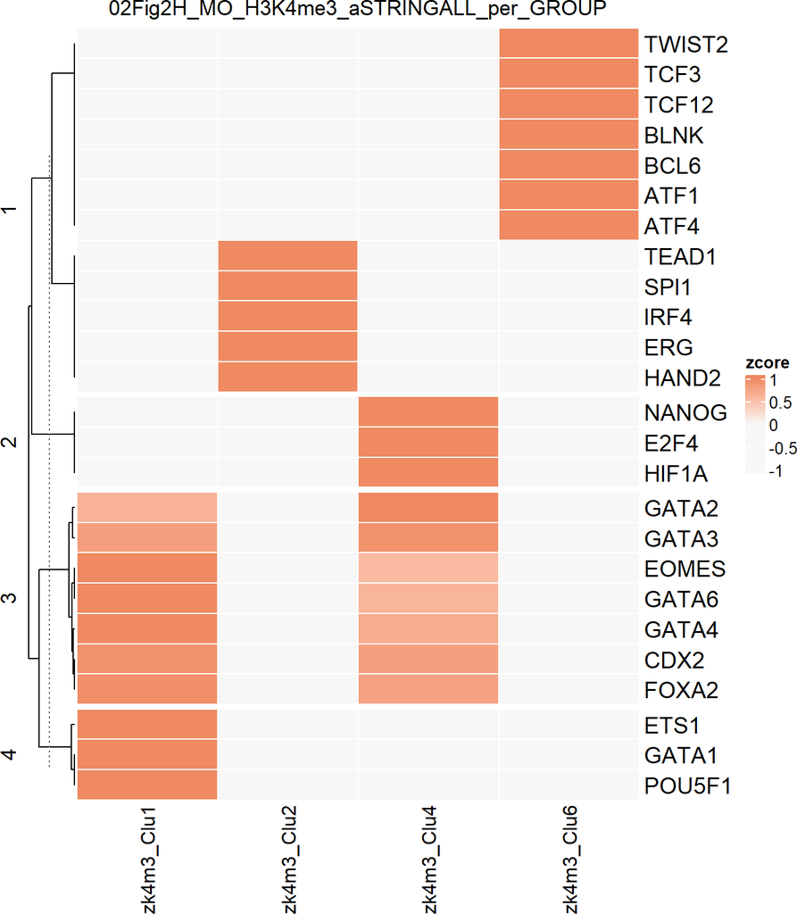

```r
print(hcm_TMM2)
```

## 7.3 Code to make the barplot as suplementary figure in the script.

-It contains top10 proteins per cluster

## 7.4 Print Barplot from the top10 protein networks

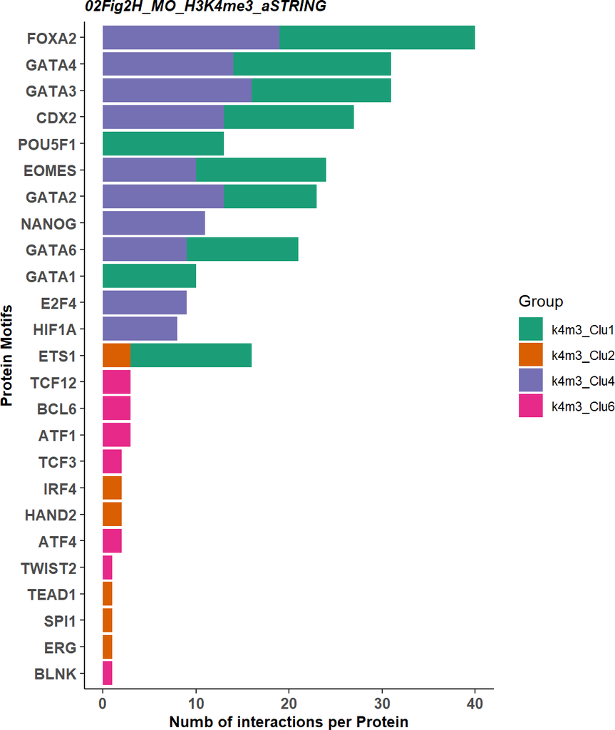

```r
print(GO04c)
```

# 8 Handling the matrixes of TFs interactions

## 8.1 Main TFs used in this stuy

- The network was performed with Cytoscape version 3.6.1

```r
PROT1="GATA4"
PROT2="ETS1"
PROT3="CDX2"

TFC0="TEAD1"
TFC01="HAND2"
TFC02="IRF4"

U1="GATA4"
U2="E2F4"
U3="HIF1A"

U11="BCL6"
U21="ATF1"
U31="TCF12"
```

## 8.2 Select TF representative from the different clusters

```r
NAME_SELEC<- c("node1","node2","CLU")
differ_4 = merge(GN5a,MAT_AA4, by= "node1")
MA7_1<- subset(differ_4, CLU==NAME_G2[1,3] ,select=NAME_SELEC)
MA7_2<- subset(differ_4, CLU==NAME_G2[2,3],select=NAME_SELEC )
MA7_3<- subset(differ_4, CLU==NAME_G2[3,3] ,select=NAME_SELEC)
MA7_4<- subset(differ_4, CLU==NAME_G2[4,3] ,select=NAME_SELEC)

PORT2<- paste(PORT,"00fCytpe","/",sep="")
dir.create(PORT2)
MA7_25_TOP10_1<- subset(MA7_1,node1==PROT1 | node1==PROT2| node1==PROT3 )
MA7_25_TOP10_2<- subset(MA7_2,node1==TFC0 | node1==TFC01 | node1==TFC02 )
MA7_25_TOP10_3<- subset(MA7_3,node1==U1 | node1==U2 | node1==U3 )
MA7_25_TOP10_4<- subset(MA7_4,node1==U11 | node1==U21 | node1==U31 )
CY="forCyto2"
write.table(MA7_25_TOP10_1,file=paste(PORT2, PROJECT,"_",NAME_G2[1,3],".txt", sep=""),sep="\t",row.names = F,col.names=T,dec=".",quote = F)
write.table(MA7_25_TOP10_2,file=paste(PORT2, PROJECT,"_",NAME_G2[2,3],".txt", sep=""),sep="\t",row.names = F,col.names=T,dec=".",quote = F)
write.table(MA7_25_TOP10_3,file=paste(PORT2, PROJECT,"_",NAME_G2[3,3],".txt", sep=""),sep="\t",row.names = F,col.names=T,dec=".",quote = F)
write.table(MA7_25_TOP10_3,file=paste(PORT2, PROJECT,"_",NAME_G2[4,3],".txt", sep=""),sep="\t",row.names = F,col.names=T,dec=".",quote = F)

TOGe<- rbind(MA7_25_TOP10_1,MA7_25_TOP10_2,MA7_25_TOP10_3,MA7_25_TOP10_4)

write.table(TOGe,file=paste(PORT2,"002_FIG1F_", PROJECT,"_A",".txt",sep=""),sep="\t",row.names = F,col.names=T,dec=".",quote = F)
write.xlsx(HHa,file=paste(PORT2,"002_FIG1F_", PROJECT,"_A",".xlsx",sep=""),rowNames=T)
write.xlsx(differ_4,file=paste(PORT, PROJECT,"_A",".xlsx", sep=""),rowNames=T)
```